# FE8828 Assignment for Exploratory Data Analysis

Yuxuan <sub><Email:yuan0080@e.ntu.edu.sg></sub>

Oct 2019

# Words at the beginning

In this assignment, I aim to use ggplot visualization to analyzing bank data sets to summarize the obviouse and clear data characteristics instead of purely building up the fancy ggplot graph. I am able to build the complicated graph like this:

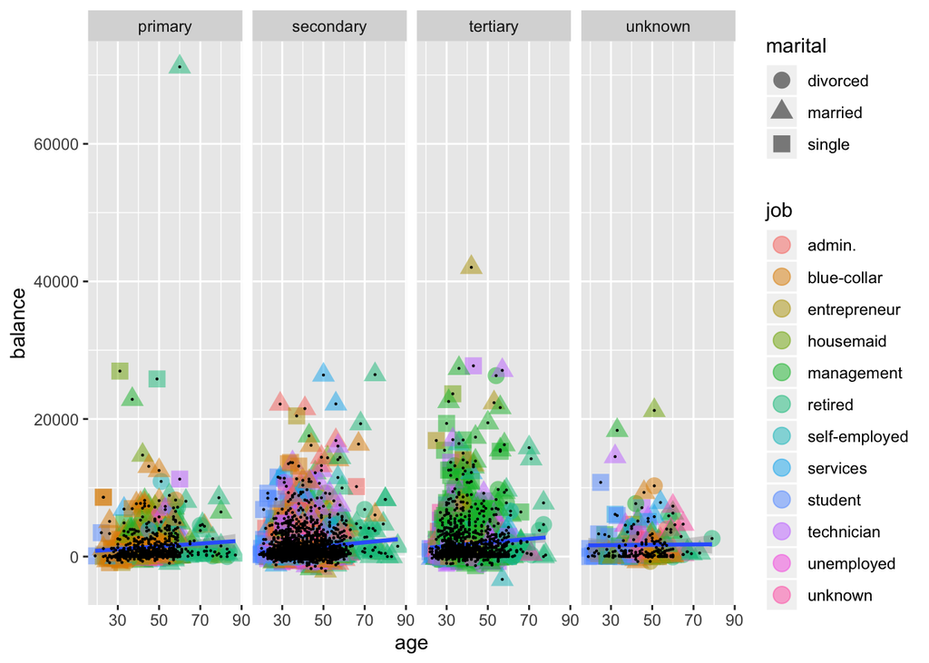

```r
g <- ggplot(bank, aes(x = age, y = balance))
g + geom_point(aes(color = job, shape = marital), size = 4, alpha = 1/2) + geom_smooth(method = "lm") + facet_grid(. ~ education) + geom_point(size = 0.1)
```

However, this ggplot above is too complicated to interpret useful information. The ggplot graphs below generally looks much simpler but easy to understand and interpret.

# Finding #1 Previous Outcome vs Previous Days

pdays is defined as “number of days that passed by after the client was last contacted from a previous campaign (numeric, -1 means client was not previously contacted)”

Disregarding the “unknown case” where client was not previously contacted (value is around -1), success cases normally have smallest pdays, and failure cases generally have the largest pdays. This graph indicates that the more recent a client was contacted, the more likely the campaign would be success on the corresponding client.

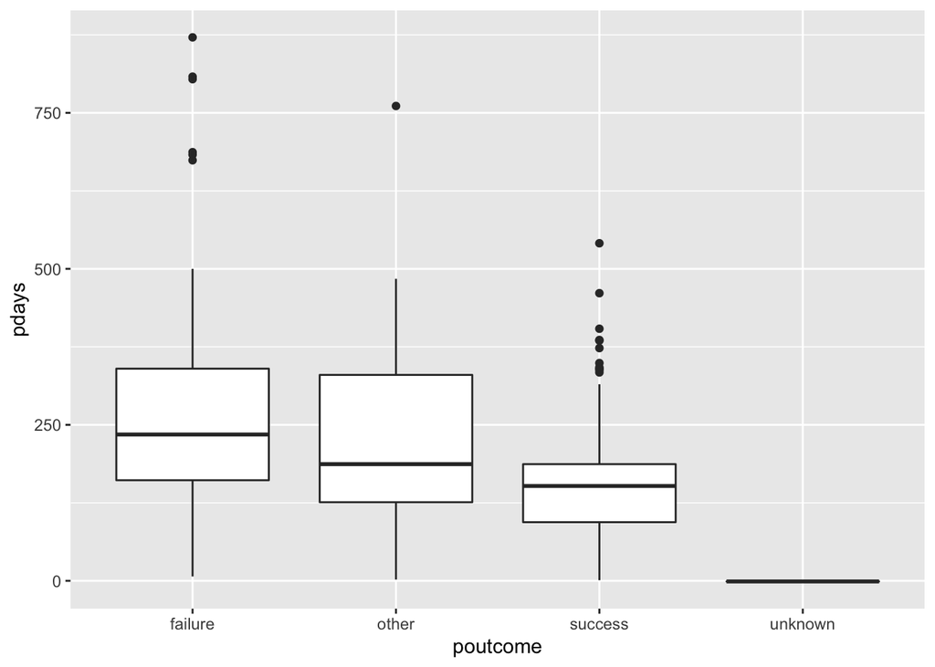

```r
ggplot(bank, aes(poutcome, pdays)) + geom_boxplot()
```

# Finding #2 Balance Distribution

The below graph shows the distribution of the client balance

- The client balance has extremely high density at around 0+, but we cannot see the exact amount from this diagram
- The reason why the x-axis can extends such long must be some outlier with extreme large value compared the the rest of the population. –> max balance is 71188, which is far from the average value 1422.6578191

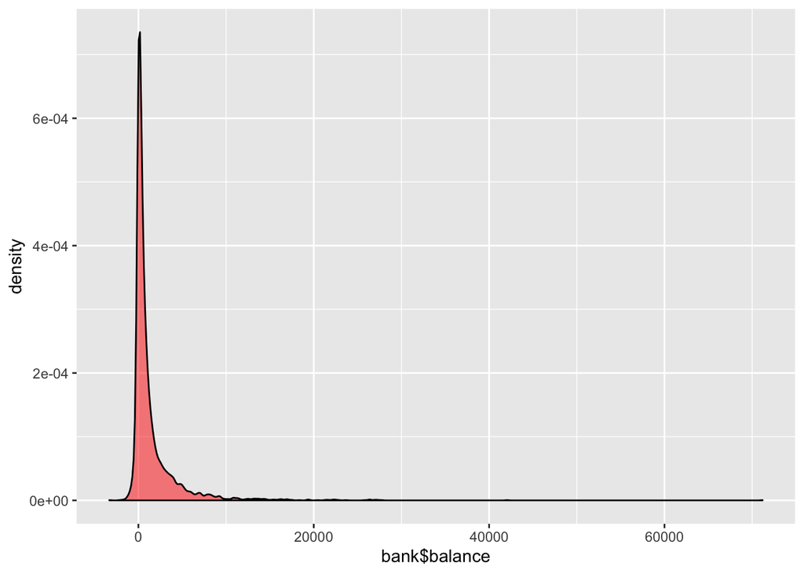

```r
# Marginal density plot
ggplot(bank, aes(bank$balance)) +
  geom_density(alpha=.5, fill = "red") +
  theme(legend.position = "none")
```

- Zooming in the graph to density area, we can see the majority fell into the balance range (-100, 1000) bacause after set x-asix limit of (-100, 1000), only 1739 out of 4521 (less than half) objects were dropped.
- The distribution of balance is obviousely right-skewed wuth a very long right tail.

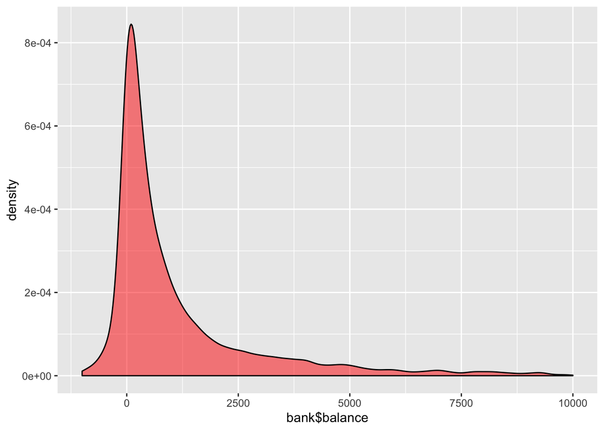

```r
#Zoom-in view
ggplot(bank, aes(bank$balance)) +
  geom_density(alpha=.5, fill = "red") +
  theme(legend.position = "none") +
  xlim(-1000, 10000)
```

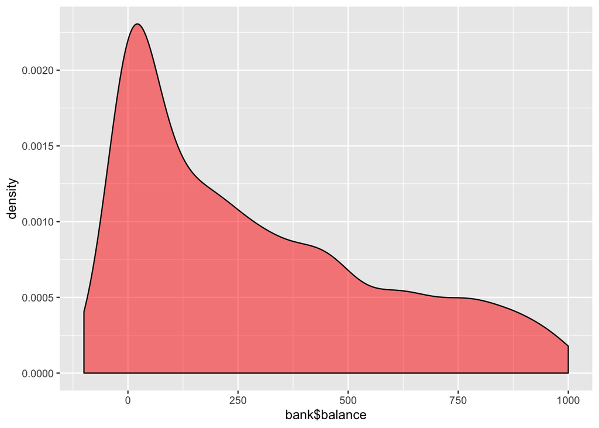

```r
#Furhter Zoom-in
ggplot(bank, aes(bank$balance)) +
  geom_density(alpha=.5, fill = "red") +
  theme(legend.position = "none") +
  xlim(-100, 1000)
```

# Finding #3: Relationship between Age vs Marital

- The average ages for single, married and divorced are increasing.
- There is no single client who is older than 70 years old.

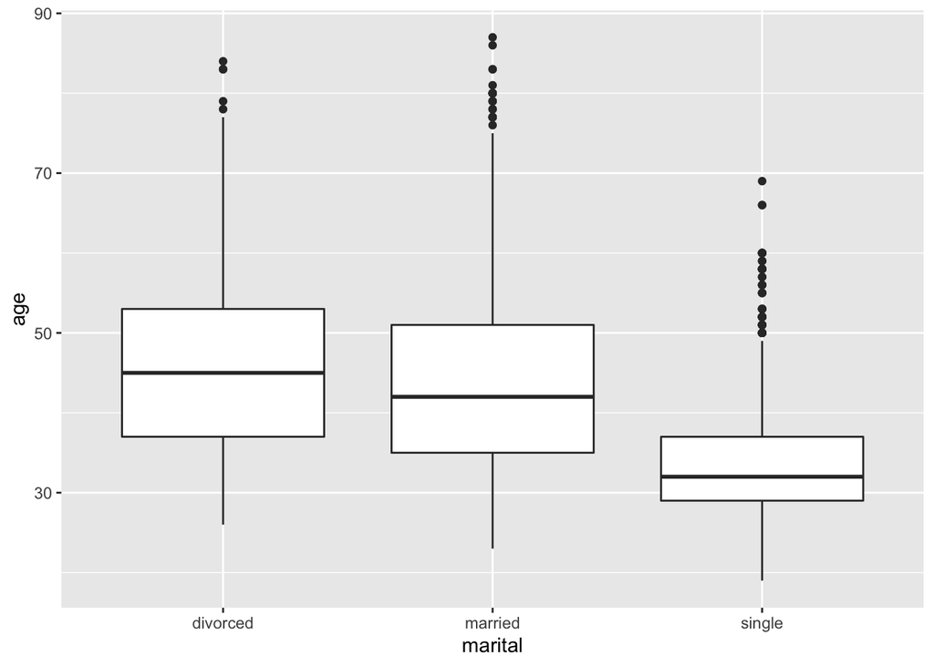

```r
ggplot(bank, aes(marital, age)) + geom_boxplot()
```

# Finding #4 Relationship between Job vs Age

For clients of this bank:

- Normally retire after 56 years old
- Majority of students are under 30 years old
- Housemaid has the largest age range.

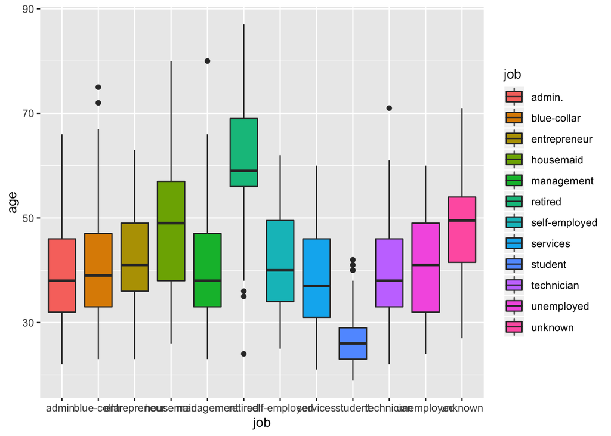

```r
ggplot(bank, aes(job, age, fill = job)) + geom_boxplot()
```

# Finding #5 Age Distribution

The below graph shows the distribution of the client ages.

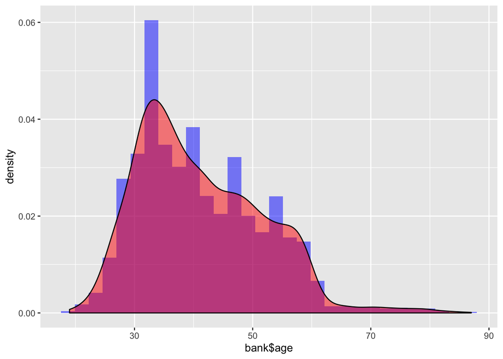

```r
# Marginal density plot
ggplot(bank, aes(bank$age)) +
  geom_histogram(aes(y=..density..), alpha=.5, fill = "blue") +
  geom_density(aes(y=..density..), alpha=.5, fill = "red") +
  theme(legend.position = "none")
## `stat_bin()` using `bins = 30`. Pick better value with `binwidth`.
```

# Finding #6 Age Group vs. poutcome

“poutcome” is defined as outcome of the previous marketing campaign (categorical:“unknown”,“other”,“failure”,“success”)

Generally, majority (more than 3/4) of the previous marketing campaign result is unknown, followed by failure and other status. Success is a reletivly rare event, with only 3% of the population

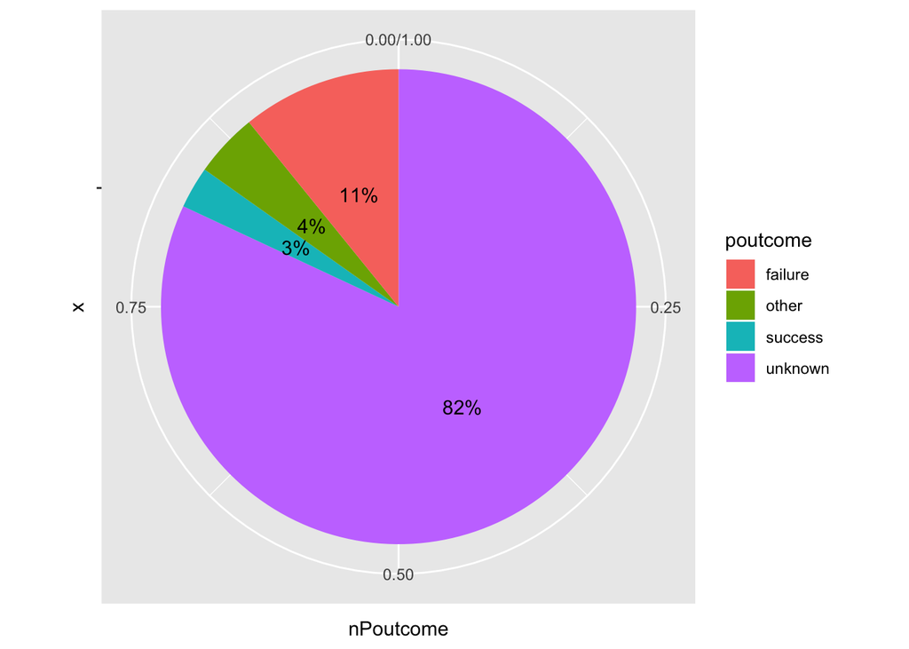

```r
bank <- mutate(bank, ageGroup = case_when(age<=30 ~ "young",
                                                    (30 < age & age <= 60) ~"middle aged",
                                                    60 <age ~ "senior"))
sum_poutcome <- group_by(bank, poutcome) %>% summarise(nPoutcome = n()/nrow(bank))
ggplot(sum_poutcome, aes(x="", y=nPoutcome, fill=poutcome)) + geom_bar(width = 1, stat = "identity") + coord_polar("y", start=0) + geom_text(aes(label = paste0(round(nPoutcome*100), "%")), position = position_stack(vjust = 0.5))
```

If we split the pie chat into different age group: “young” if age is smaller or equals to 30; “middle aged” if age is between 30 and 60 (right side inclusive); “senior” if age is larger than 60. The general trend follows for young and middle-aged clients. However, in the case of senior client, the success rate is 13%, which is much higher than that of other age groups. This indicate that the marketing department should pay more efforts to senior clients because they are more possible to accept the marketing campaign.

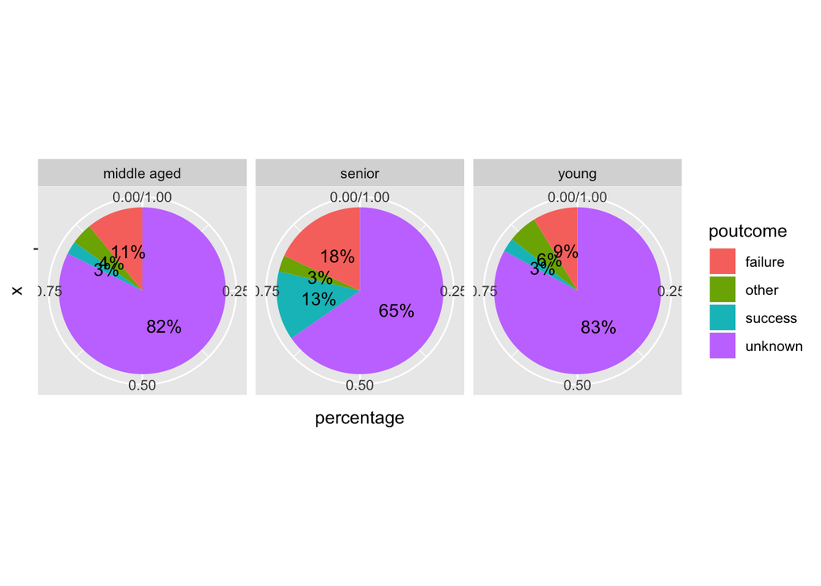

```r
sum_ageGroup <- group_by(bank, ageGroup) %>% summarise(nAge = n())
sum_ageGroup_poutcome <- group_by(bank, ageGroup,  poutcome) %>% summarise(n = n())
sum_ageGroup_poutcome <- right_join(sum_ageGroup_poutcome, sum_ageGroup, by = "ageGroup")
sum_ageGroup_poutcome <- mutate(sum_ageGroup_poutcome, percentage = n/nAge)
ggplot(sum_ageGroup_poutcome, aes(x="", y=percentage, fill=poutcome)) + geom_bar(width = 1, stat = "identity") + coord_polar("y", start=0)  + geom_text(aes(label = paste0(round(percentage*100), "%")), position = position_stack(vjust = 0.5)) + facet_grid( ~ ageGroup)
```

# Finding #7 Job vs. Education

Based on the following two barcharts with percentage fill, we can see the relationship between jon and education level.

- Jobs such as management and services have high preference with eduction level
  - Majority of management has tertinary education
  - Majroity of services has secondary eductaion
- People with different education background have different job distribution/opprotunities
  - People with primary education have more likelihood to become blue-collar. They have very litter chance to work as entrepreneur, admin, self-employed and technician
  - Admin, blue-collar, services and technican are the main job selections for people with secondary eductaion
  - Majority of people with teriary eductation work as management, and seldom work as blue-collar and services
  - Unemployed rate is low in all of the three education levels.

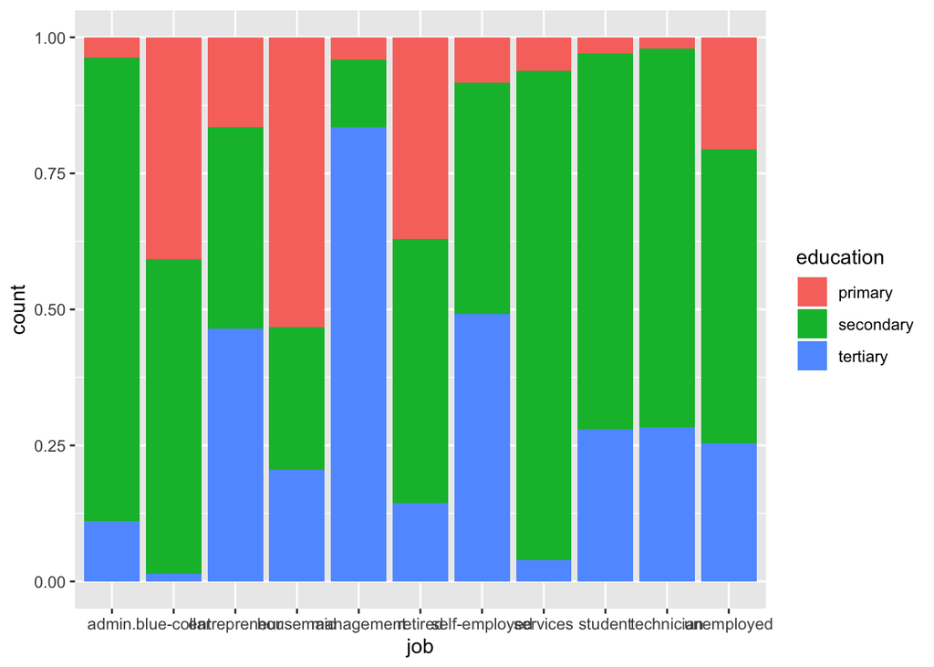

```r
#filter out unknown data for better analyse
bank_after_filter_unknown_education <- filter(bank, education!='unknown'&job!='unknown')
ggplot(bank_after_filter_unknown_education) + geom_bar(mapping = aes(x = job, fill = education),position = "fill")
```

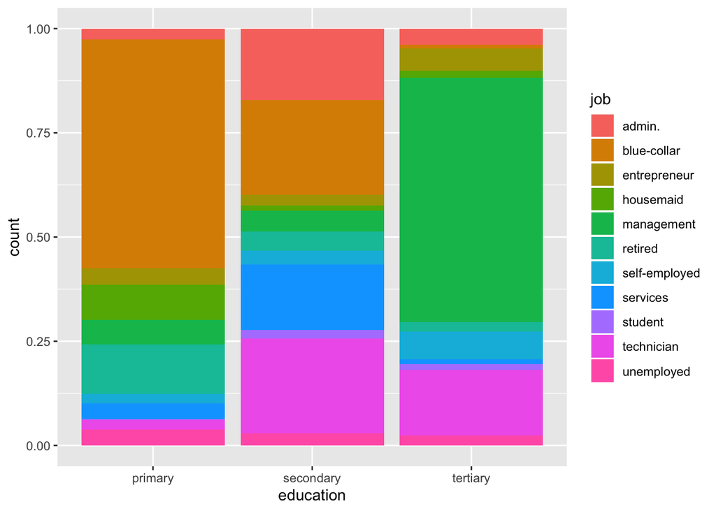

```r
ggplot(bank_after_filter_unknown_education) + geom_bar(mapping = aes(x = education, fill = job),position = "fill")
```

# Finding #8 Balance vs Duration

The average duration for any balance amount is constantly around 250 seconds. The curve is generally horizontally straight, which indicates that the duration is uncorrelated with client’s balance. The shadow area for extreme small and big balance amount is larger because the corresponding sample size is too small to make accurate estimation.

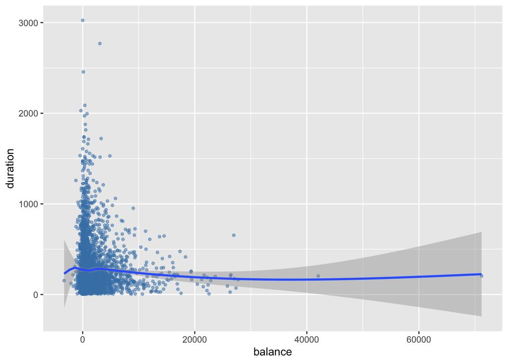

```r
g <- ggplot(bank, aes(x = balance, y = duration))
g + geom_point(color = "steelblue", size = 1, alpha = 1/2) + geom_smooth()
## `geom_smooth()` using method = 'gam' and formula 'y ~ s(x, bs = "cs")'
```

# Finding #9 Default vs Balance

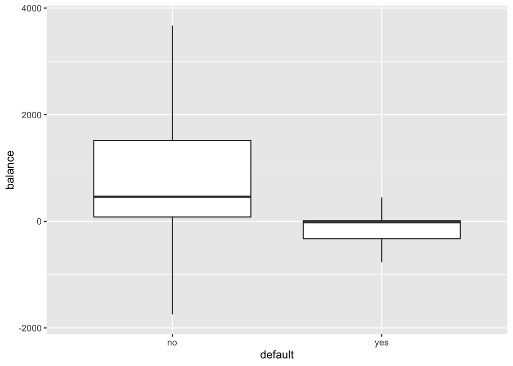

```r
#Not showing outliers to have better visualization
p0 = ggplot(bank, aes(default, balance)) + geom_boxplot(outlier.shape = NA)
# compute lower and upper whiskers
ylim1 = boxplot.stats(bank$balance)$stats[c(1, 5)]
# scale y limits based on ylim1
p0 + coord_cartesian(ylim = ylim1*1.05)
```

# Finding #10 Duration vs Age & Contact

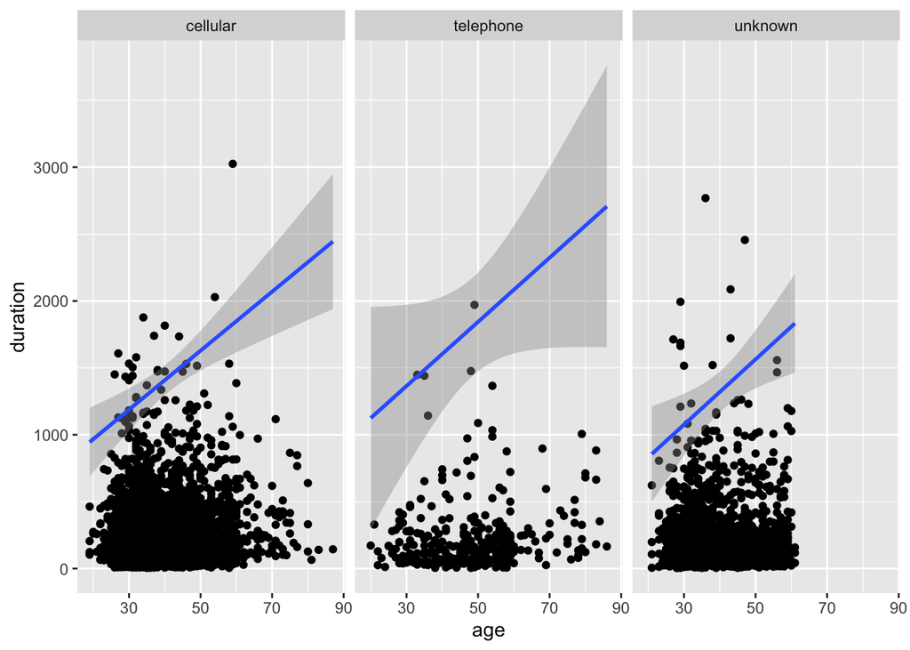

```r
ggplot(data = bank) +
geom_point(mapping = aes(x = age, y = duration)) + geom_smooth(aes(x = age, y = balance), method = 'lm') +
facet_grid( ~ contact)
```